# A3: Incarceration

### Introduction

America: Home of freedom, lawsuits, and prisons. The United States boasts of the greatest number of people incarcerated in the world, with 1,767,200 people imprisoned.[^1] Within this rate, civil rights group and activists have pointed out that certain groups of people have been disproportionately imprisoned. With our dataset from the Vera Institute, we will examine the patterns concerning the incarceration rates of different ethnic groups as well as the changes of these over time. We also want to examine incarceration rates geographically and identify the states with the highest rates of incarceration. Answering these questions will reveal how disproportionate the rates of incarceration between ethnicity and explain how important this problem is. We can also gather evidence for identifying the causes of the incarceration of certain ethnic groups.

### Summary Information

Our data contains data from 1990 to 2018 from 3139 counties. An initial look at the data reveals that the rate of incarceration in the United States is indeed very high: About 700 out of 100,000 people in the United States are incarcerated. This would mean, since the US population was 326.8 million in 2018, about 2 million people are incarcerated in 2018. We have also found that Oklahoma has the highest rate of incarceration, at an average of 1096 per 100,000 people incarcerated per county. We will break down this data into ethnicity and examine how the rates per ethnicity change over time.

| Detail | Values |
| --- | --- |
| Year Range | 1990 - 2018 |
| Number of Counties | 3139 |
| Average Prison Incarceration Rate | 700.229292885203 |
| Highest Rate of Prison Incarcerations | 8737.86 |
| State w/ Highest Incarceration | OK |

### The Dataset

Our data is collected by the Vera Institute of Justice[^2], which is an organization advocating for criminal reform to “end mass incarceration”. Their data is for county jails is collected from National Corrections Reporting Program, and their prison data is collected from state records. Vera collects this data to provide evidence for the movement against mass incarceration within the United States. The dataset contains 23 columns and 91031 rows.

There are many ethical concerns considering that this data concerns ethnicity. Identity is a complicated matter, and we are simplifying it by categorizing prisoners based off only ethnicity. Socioeconomic situations, policing, and policies all affect our data but are not represented. It is possible our data can be used to support flawed viewpoints, but this is the unfortunate result of this simplification. Our data also is not the most recent. This data is suitable for understanding historical incarcerations to help understand this issue today, but it is possible that current events have changed the incarceration problem. We must be careful to keep the scope of our conclusions limited, as our data is also limited.

Our data is sourced from county and state records, which may not capture every year we are examining. The missing data points therefore skews our conclusions, which means our observations may not be accurate as possible. However, our data should be sufficient for the study we are performing.

### Trends Over Time Chart

In this chart, we examine the prison incarceration rates of each ethnicity from 1990 to 2018. We wanted to examine the changes in these rates over time as well as the consistencies within the data. What the graph shows is clear: African Americans face significant rates of incarceration, disproportionate to their population. All ethnicities have had increased incarceration rates from 1990 to 2018 on average, although AAPI Americans have had the lowest increase in rates. There also seems to have been spikes within ethnicities, most clearly seen in African Americans and Latinos. However, these spikes do not seem to be related, as they occur during separate time periods.

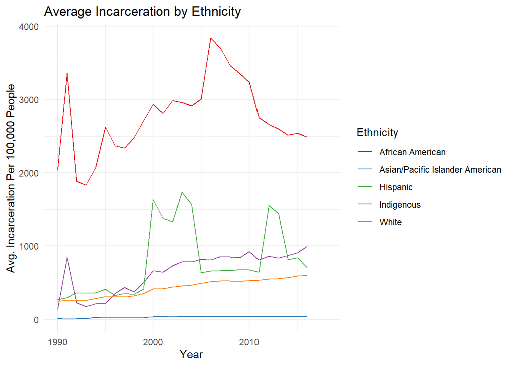

### Variable Comparison Chart

For this chart, we compared prison and jail populations. Prisons and jails are not the same thing: Prison are for the convicted, whereas jails are for the suspected. Not everyone that goes to jail is sent to prison, so comparing this data can possibly give us insight into the conviction rates of ethnicities. Sadly, rates are still extremely high for blacks. Asians, blacks, latinos, and indigenous people have a higher jail rate than whites. The proportions are similar for prison rates, although noticiably AAPI people have a significantly lower rate when compared to all other ethnicities and their own jail rates.

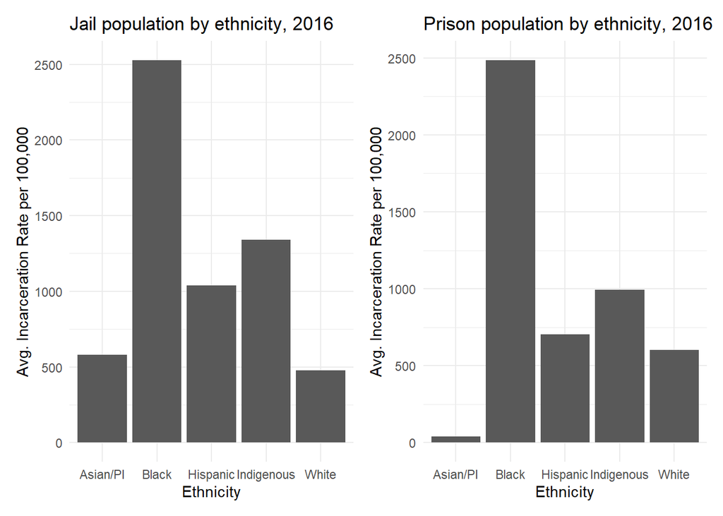

### Map

This map illustrates the rates of incarceration in the US, for 2016 (Grey states represent no data). If there were no disparities for incarceration, then we would expect this map to closely match the population distribution of the US. This is obviously not the case. We expected certain states with particularly high populations, such as California, New York, and Washington, to some of the highest rates of incarceration, but our prediction was disproven. Instead, it seems that incarcerate rates are especially higher in south east America. What this tells us is that there are factors in the southeast that cause this abnormal rate of incarceration.

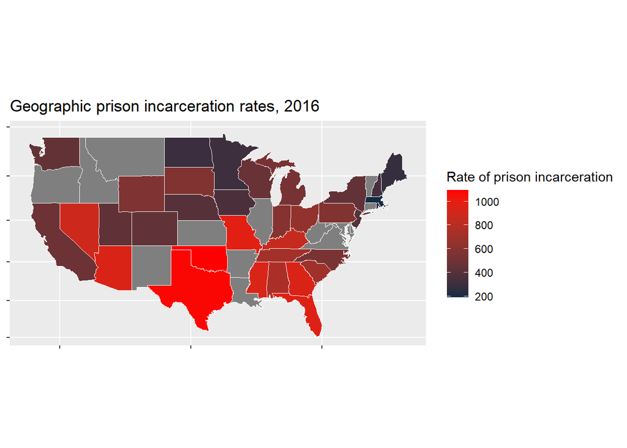

[^1]: https://worldpopulationreview.com/country-rankings/incarceration-rates-by-country
[^2]: https://www.vera.org/who-we-are/about-us